##### Author: Ayoub Gouriba

#### Course: GISY6060 - Assignment 5 | NSCC - Centre of Geographic Sciences

# Introduction

In this Jupyter Notebook, we analyze the walking street network in downtown Ottawa (also known as Somerset, Ottawa). We will be using various libraries such as Pandas, Geopandas, OSMnx, NetworkX, and Shapely to work with the street network data. We will visualize different layers of data such as buildings, points of interest, parks, and generate isochrones. Finally, we will calculate street network indicators such as basic street network measures, density-based statistics, and betweenness centrality.

## Load libraries

```python
import pandas as pd
import geopandas as gpd
import osmnx as ox
import networkx as nx
import matplotlib.pyplot as plt
from shapely.geometry import LineString
from shapely.geometry import Point
from shapely.geometry import Polygon

%matplotlib inline
```

## Declare variables and generate graph

```python
#Specify the name that is used to seach for the data
place_name = "Somerset, Ottawa" #Ottawa
profile = "walk"
# Fetch OSM street network from the location
graph = ox.graph_from_place(place_name, network_type = profile)
```

## Visualise walking street network

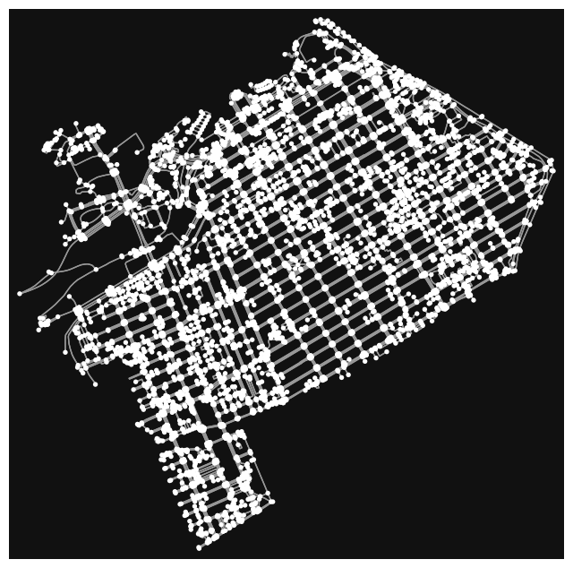

```python
# Plot the streets
fig, ax = ox.plot_graph(graph)
```

## Place area polygon

Visualise the downtown area as a polygon so we can use it as a background for plotting

```python
area = ox.geocode_to_gdf(place_name) # returns a GeoDataFrame based on the specified place name query
```

```python
area # check data
```

|  | geometry | bbox_north | bbox_south | bbox_east | bbox_west | place_id | osm_type | osm_id | lat | lon | display_name | class | type | importance |
| --- | --- | --- | --- | --- | --- | --- | --- | --- | --- | --- | --- | --- | --- | --- |
| 0 | POLYGON ((-75.72887 45.41721, -75.72676 45.413... | 45.428159 | 45.396869 | -75.680308 | -75.728866 | 299040140 | relation | 7101979 | 45.412783 | -75.704694 | Somerset, (Old) Ottawa, Ottawa, Eastern Ontari... | boundary | administrative | 0.52001 |

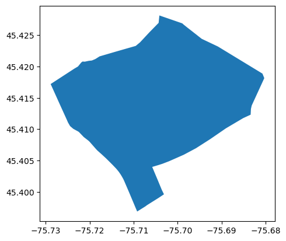

```python
area.plot()
```

## Building footprints

Generating building footprints by using the building tag from OSM

```python
buildings = ox.geometries_from_place(place_name, tags={'building':True}) # Retrieve buildings from the area:
```

```python
len(buildings) # Check how many building footprints we received:
```

```
5603
```

We have a total of 5603 building footprints in the neighbrhood, let's check the first 3:

```python
buildings.head(3) # Check the first rows
```

| element_type | osmid | addr:housenumber | addr:street | source | geometry | amenity | parking | capacity | fee | name | opening_hours | ... | building:min_level | inscription | material | monument | opening_date | ways | type | designation | name:ja | name:sv |
| --- | --- | --- | --- | --- | --- | --- | --- | --- | --- | --- | --- | --- | --- | --- | --- | --- | --- | --- | --- | --- | --- | --- |
| way | 9933590 | NaN | NaN | NaN | POLYGON ((-75.71306 45.41389, -75.71280 45.413... | NaN | NaN | NaN | NaN | NaN | NaN | ... | NaN | NaN | NaN | NaN | NaN | NaN | NaN | NaN | NaN | NaN |
|  | 31813255 | 71 | Somerset Street West | City of Ottawa | POLYGON ((-75.68735 45.41956, -75.68719 45.419... | NaN | NaN | NaN | NaN | Ann Manor | NaN | ... | NaN | NaN | NaN | NaN | NaN | NaN | NaN | NaN | NaN | NaN |
|  | 31813256 | 10 | The Driveway | City of Ottawa | POLYGON ((-75.68623 45.42035, -75.68609 45.420... | NaN | NaN | NaN | NaN | NaN | NaN | ... | NaN | NaN | NaN | NaN | NaN | NaN | NaN | NaN | NaN | NaN |

3 rows × 177 columns

```python
buildings.columns # the building features have 177 columns making them very rich in information
```

```
Index(['addr:housenumber', 'addr:street', 'source', 'geometry', 'amenity',
       'parking', 'capacity', 'fee', 'name', 'opening_hours',
       ...
       'building:min_level', 'inscription', 'material', 'monument',
       'opening_date', 'ways', 'type', 'designation', 'name:ja', 'name:sv'],
      dtype='object', length=177)
```

## Points-of-interest

Let's retrieve different points of interest from OSM data within our area.

### Restaurants

```python
# Retrieve restaurants
restaurants = ox.geometries_from_place(place_name,
                                  tags={"amenity": "restaurant"}
                                 )
```

```python
# How many restaurants do we have?
len(restaurants)
```

```
198
```

```python
# Available columns
restaurants.columns
```

```
Index(['addr:housenumber', 'addr:street', 'amenity', 'name', 'geometry',
       'cuisine', 'mapillary', 'phone', 'website', 'name:en', 'name:zh',
       'opening_hours', 'check_date', 'wheelchair', 'alt_name',
       'addr:postcode', 'diet:vegan', 'brand', 'brand:wikidata',
       'outdoor_seating', 'note', 'smoking', 'takeaway', 'delivery',
       'internet_access', 'source', 'capacity', 'name:ur', 'email',
       'brand:wikipedia', 'name:fr', 'official_name', 'addr:unit',
       'diet:vegetarian', 'level', 'contact:instagram', 'addr:city',
       'addr:province', 'name:zh-Hans', 'name:zh-Hant', 'shop', 'nodes',
       'building', 'building:levels', 'survey:date'],
      dtype='object')
```

```python
# Select some useful cols and print
cols = ['name', 'cuisine']

# Print only selected cols
restaurants[cols].head(10)
```

| element_type | osmid | name | cuisine |
| --- | --- | --- | --- |
| node | 600101630 | Zak's Diner | NaN |
|  | 778695498 | Gibsons on Queen | NaN |
|  | 808468420 | Festival Japan | japanese |
|  | 967976461 | Oriental Chu Shing | chinese |
|  | 967976470 | So Good Restaurant | chinese |
|  | 967976471 | Ben Ben Restaurant | chinese |
|  | 1143319495 | Harmony Restaurant | NaN |
|  | 1144102566 | Pure Kitchen | NaN |
|  | 1144102577 | St. Louis Bar & Grill | chicken |
|  | 1540354453 | Giulia | italian |

### Waterways

```python
# Retrieve waterways
waterways = ox.geometries_from_place(place_name, tags={'waterway': True})
waterways.head(3)
```

| element_type | osmid | seamark:type | waterway | geometry | name | nodes | landuse | lock | lock_name | lock_ref | phone | ... | name:moh | name:oj | man_made | substance | usage | location | covered | oneway | ways | type |
| --- | --- | --- | --- | --- | --- | --- | --- | --- | --- | --- | --- | --- | --- | --- | --- | --- | --- | --- | --- | --- | --- | --- |
| way | 39453398 | NaN | dam | POLYGON ((-75.72124 45.41914, -75.72130 45.419... | Ring Dam | [10299325143, 5329659843, 5329659844, 56634927... | industrial | NaN | NaN | NaN | NaN | ... | NaN | NaN | NaN | NaN | NaN | NaN | NaN | NaN | NaN | NaN |
|  | 39639208 | NaN | dam | LINESTRING (-75.71709 45.41959, -75.71702 45.4... | NaN | [475162568, 475496164, 32952364] | NaN | NaN | NaN | NaN | NaN | ... | NaN | NaN | NaN | NaN | NaN | NaN | NaN | NaN | NaN | NaN |
|  | 42800579 | NaN | canal | LINESTRING (-75.69534 45.42487, -75.69572 45.4... | Ottawa Locks | [535227702, 538410321, 538410322, 538410371, 5... | NaN | yes | Ottawa Locks | 1,2,3,4,5,6,7,8 | +1-613-237-2309 | ... | NaN | NaN | NaN | NaN | NaN | NaN | NaN | NaN | NaN | NaN |

3 rows × 33 columns

### Parks

```python
# Retrieve leisure points
leisure = ox.geometries_from_place(place_name, tags={'leisure':True}) # fetch data
leisure.head(3) #check data
```

| element_type | osmid | highway | geometry | addr:housenumber | addr:postcode | addr:street | check_date | leisure | name | sport | amenity | ... | contact:twitter | survey:date | operator:short | club | fixme | ft_link | garden:type | ways | type | dogs |
| --- | --- | --- | --- | --- | --- | --- | --- | --- | --- | --- | --- | --- | --- | --- | --- | --- | --- | --- | --- | --- | --- | --- |
| node | 1415542336 | NaN | POINT (-75.71646 45.40865) | 145 | K1R 6P1 | Spruce Street West | 2022-10-16 | fitness_centre | Beaver Boxing Club | boxing | NaN | ... | NaN | NaN | NaN | NaN | NaN | NaN | NaN | NaN | NaN | NaN |
|  | 3671180074 | NaN | POINT (-75.69527 45.41429) | NaN | NaN | NaN | NaN | fitness_centre | Pure Yoga | yoga | NaN | ... | NaN | NaN | NaN | NaN | NaN | NaN | NaN | NaN | NaN | NaN |
|  | 4356187622 | NaN | POINT (-75.69795 45.42534) | NaN | NaN | NaN | NaN | picnic_table | NaN | NaN | NaN | ... | NaN | NaN | NaN | NaN | NaN | NaN | NaN | NaN | NaN | NaN |

3 rows × 117 columns

```python
leisure["leisure"].value_counts() # check all values for the column
```

```
picnic_table                    106
park                             33
fitness_centre                   32
playground                       29
pitch                            17
garden                           17
swimming_pool                     7
ice_rink                          6
dance                             4
sports_centre                     4
table                             3
dog_park                          2
hackerspace                       1
amusement_arcade                  1
escape_game                       1
swimming_pool; sports_centre      1
Name: leisure, dtype: int64
```

In downtown Ottawa, there is 33 parks, 29 playgrounds and 17 pitches, let's add them to a variable called parks:

```python
parks = leisure[leisure["leisure"].isin(["pitch","park","playground"])] # select all park polygons
```

## Graph to GeoDataFrame

In this section, we convert the graph representation of the street network to GeoDataFrames for nodes and edges. This will allow us to perform more advanced geospatial analysis and visualization using Geopandas and Matplotlib.

```python
# Retrieve nodes and edges
nodes, edges = ox.graph_to_gdfs(graph)
```

```python
nodes.head()
```

| osmid | y | x | street_count | highway | geometry |
| --- | --- | --- | --- | --- | --- |
| 31280109 | 45.416196 | -75.718411 | 3 | NaN | POINT (-75.71841 45.41620) |
| 32925459 | 45.422581 | -75.702551 | 4 | stop | POINT (-75.70255 45.42258) |
| 32925471 | 45.424557 | -75.696552 | 3 | NaN | POINT (-75.69655 45.42456) |
| 32925485 | 45.424125 | -75.700858 | 3 | NaN | POINT (-75.70086 45.42412) |
| 32953544 | 45.412566 | -75.709942 | 3 | NaN | POINT (-75.70994 45.41257) |

```python
edges.head()
```

| u | v | key | osmid | highway | service | oneway | reversed | length | lanes | name | geometry | maxspeed | width | ref | bridge | access | tunnel |
| --- | --- | --- | --- | --- | --- | --- | --- | --- | --- | --- | --- | --- | --- | --- | --- | --- | --- |
| 31280109 | 6872396973 | 0 | 733781160 | service | driveway | False | False | 5.513 | NaN | NaN | LINESTRING (-75.71841 45.41620, -75.71843 45.4... | NaN | NaN | NaN | NaN | NaN | NaN |
|  | 6355742548 | 0 | 4852253 | residential | NaN | False | False | 98.360 | 2 | Vimy Place | LINESTRING (-75.71841 45.41620, -75.71727 45.4... | NaN | NaN | NaN | NaN | NaN | NaN |
|  | 1194392552 | 0 | 4852253 | residential | NaN | False | True | 78.556 | 2 | Vimy Place | LINESTRING (-75.71841 45.41620, -75.71924 45.4... | NaN | NaN | NaN | NaN | NaN | NaN |
| 32925459 | 6370634349 | 0 | 31773792 | unclassified | NaN | False | True | 6.187 | 2 | Vittoria Street | LINESTRING (-75.70255 45.42258, -75.70262 45.4... | 30 | NaN | NaN | NaN | NaN | NaN |
|  | 6370634351 | 0 | 443492346 | service | driveway | False | False | 8.573 | NaN | NaN | LINESTRING (-75.70255 45.42258, -75.70244 45.4... | NaN | NaN | NaN | NaN | NaN | NaN |

## Plotting data

In this section, we create a comprehensive visualization of the study area by plotting various geographical features on a single map. We use Matplotlib to generate the plot.

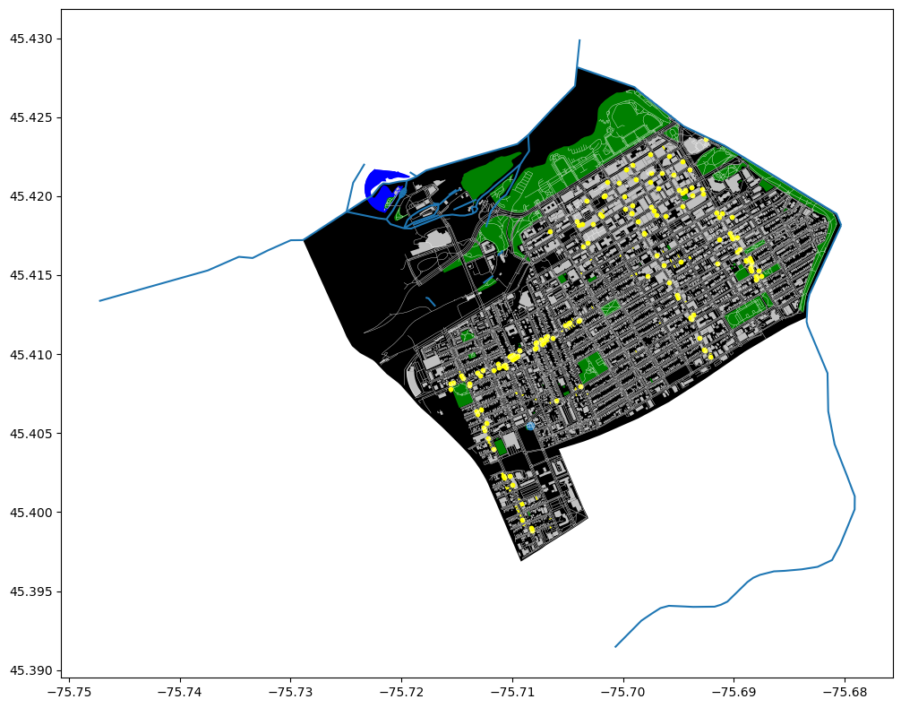

```python
fig, ax = plt.subplots(figsize=(12,8))

# Plot the footprint
area.plot(ax=ax, facecolor='black')

# Plot street edges
edges.plot(ax=ax, linewidth=0.3, alpha=0.5, edgecolor='white')

# Retrieve waterways
waterways.plot(ax=ax, facecolor="blue")

# Plot buildings
buildings.plot(ax=ax, facecolor='silver', alpha=1)

# Plot the parks
parks.plot(ax=ax, facecolor="green")

# Plot restaurants
restaurants.plot(ax=ax, color='yellow', alpha=1, markersize=10)
plt.tight_layout()
```

## Isochrones

Isochrones are lines on a map that connect points with equal travel time from a specific location. They help visualize the reachability of a location within a certain time frame. In this section, we will generate isochrones for our study area based on walking times.

Set up parameters: We define the trip_times in minutes (5, 10, 15, 20, 25) and travel_speed in km/hour (4.5 for walking) to be used for generating isochrones.

```python
trip_times = [5, 10, 15, 20, 25]  # in minutes
travel_speed = 4.5  # walking speed in km/hour
```

Find centermost node: We find the centroid of the study area by converting nodes to a GeoDataFrame, then calculating the unary union of their geometries. We find the nearest node to the centroid and project the graph to UTM (Universal Transverse Mercator) coordinates.

```python
# find the centermost node and then project the graph to UTM
gdf_nodes = ox.graph_to_gdfs(graph, edges=False)
x, y = gdf_nodes["geometry"].unary_union.centroid.xy
center_node = ox.distance.nearest_nodes(graph, x[0], y[0])
graph = ox.project_graph(graph)
```

Add edge attribute for time: We convert the travel speed from km/hour to meters/minute and calculate the time in minutes required to traverse each edge in the graph. We add this attribute to the graph's edge data.

```python
# add an edge attribute for time in minutes required to traverse each edge
meters_per_minute = travel_speed * 1000 / 60  # km per hour to m per minute
for _, _, _, data in graph.edges(data=True, keys=True):
    data["time"] = data["length"] / meters_per_minute
```

Assign colors for isochrones: We use the ox.plot.get_colors() function to generate a color for each isochrone based on a color map ("plasma").

```python
# get one color for each isochrone
iso_colors = ox.plot.get_colors(n=len(trip_times), cmap="plasma", start=0, return_hex=True)
```

Create isochrone polygons: We define a function make_iso_polys() that takes the graph and buffers for nodes and edges as input and returns isochrone polygons. The function iterates through each trip time, creates a subgraph, generates node points and edge lines, and buffers the nodes and edges. It then unifies the buffered geometries to create the isochrone polygon for each trip time.

```python
def make_iso_polys(graph, edge_buff=25, node_buff=50, infill=False):
    isochrone_polys = []
    for trip_time in sorted(trip_times, reverse=True):
        subgraph = nx.ego_graph(graph, center_node, radius=trip_time, distance="time")

        node_points = [Point((data["x"], data["y"])) for node, data in subgraph.nodes(data=True)]
        nodes_gdf = gpd.GeoDataFrame({"id": list(subgraph.nodes)}, geometry=node_points)
        nodes_gdf = nodes_gdf.set_index("id")

        edge_lines = []
        for n_fr, n_to in subgraph.edges():
            f = nodes_gdf.loc[n_fr].geometry
            t = nodes_gdf.loc[n_to].geometry
            edge_lookup = graph.get_edge_data(n_fr, n_to)[0].get("geometry", LineString([f, t]))
            edge_lines.append(edge_lookup)

        n = nodes_gdf.buffer(node_buff).geometry
        e = gpd.GeoSeries(edge_lines).buffer(edge_buff).geometry
        all_gs = list(n) + list(e)
        new_iso = gpd.GeoSeries(all_gs).unary_union

        # try to fill in surrounded areas so shapes will appear solid and
        # blocks without white space inside them
        if infill:
            new_iso = Polygon(new_iso.exterior)
        isochrone_polys.append(new_iso)
    return isochrone_polys
```

Generate isochrone polygons: We call the make_iso_polys() function with appropriate parameters to generate the isochrone polygons. We then convert the isochrone polygons to a GeoDataFrame to facilitate plotting.

```python
# make the isochrone polygons
isochrone_polys = make_iso_polys(graph, edge_buff=25, node_buff=0, infill=True)
gdf = gpd.GeoDataFrame(geometry=isochrone_polys)
```

Plot the graph and isochrones: We first plot the graph using the ox.plot_graph() function. Then, we add the isochrone polygons on top of the graph using the gdf.plot() method, setting the colors, edge colors, and other visualization parameters.

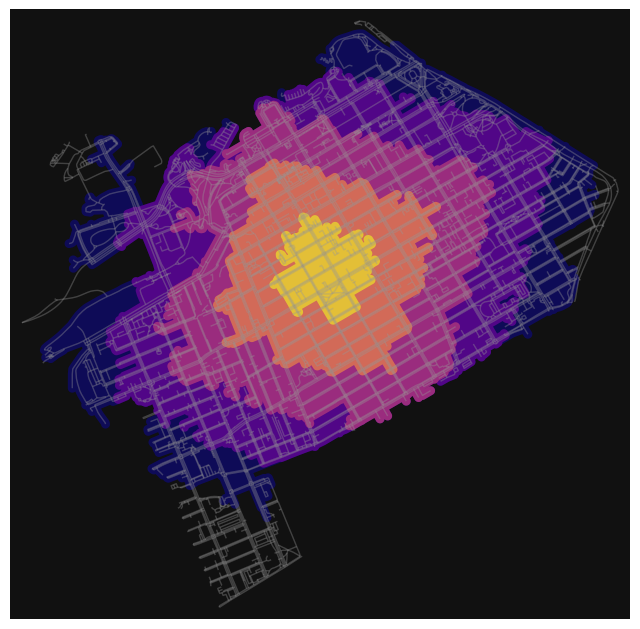

```python
# plot the network then add isochrones as colored polygon patches
fig, ax = ox.plot_graph(
    graph, show=False, close=False, edge_color="#999999", edge_alpha=0.2, node_size=0
)
gdf.plot(ax=ax, color=iso_colors, ec="none", alpha=0.6, zorder=-1)
plt.show()
```

Most of downtown can be reached within a 25-minute walk from the centroid of the study area. This indicates good walkability and accessibility within the downtown Ottawa area.

## Street network indicators

In this section, we calculate various street network indicators for a given area (Somerset, Ottawa) and display the results. The indicators help us understand the structure, connectivity, and complexity of the street network in the area.

### Calculate basic street network measures (topological and geometric)

We use the ox.basic_stats() function to calculate basic statistics for the graph. We also display the average circuity (1.03), which indicates how much longer the actual routes in the network are compared to direct routes.

```python
# get the network for Somerset, Ottawa, calculate its basic stats, then show the average circuity
stats = ox.basic_stats(graph)
stats["circuity_avg"]
```

```
1.0329089556754472
```

Calculate area-based stats: To calculate area-based statistics, we need to provide the bounding area of the street network in square meters. We use ox.geocode_to_gdf() to get the GeoDataFrame of the place and calculate its area using ox.project_gdf() and unary_union.area.

```python
# get the street network for a place, and its area in square meters
gdf = ox.geocode_to_gdf(place_name)
area = ox.project_gdf(gdf).unary_union.area
```

Calculate and display stats: We call the ox.basic_stats() function again, passing the area as an argument, and store the results in a pandas Series. The output displays various indicators such as the number of nodes, the number of edges, average node degree, total edge length, average edge length, and more.

```python
# calculate basic and extended network stats, merge them together, and display
stats = ox.basic_stats(graph, area=area)
pd.Series(stats)
```

```
n                                                                            6067
m                                                                           19320
k_avg                                                                    6.368881
edge_length_total                                                      617290.002
edge_length_avg                                                         31.950828
streets_per_node_avg                                                     3.199275
streets_per_node_counts         {0: 0, 1: 744, 2: 0, 3: 2682, 4: 2588, 5: 50, ...
streets_per_node_proportions    {0: 0.0, 1: 0.12263062469095104, 2: 0.0, 3: 0....
intersection_count                                                           5323
street_length_total                                                    308645.001
street_segment_count                                                         9660
street_length_avg                                                       31.950828
circuity_avg                                                             1.032909
self_loop_proportion                                                     0.000932
node_density_km                                                        924.329764
intersection_density_km                                                810.978627
edge_density_km                                                      94046.402107
street_density_km                                                    47023.201053
dtype: object
```

Unpack nested dicts: The streets per node counts and proportions are nested dictionaries in the stats object. We unpack them into individual keys and values, so they can be displayed and analyzed more easily.

```python
# unpack dicts into individiual keys:values
stats = ox.basic_stats(graph, area=area)
for k, count in stats["streets_per_node_counts"].items():
    stats["{}way_int_count".format(k)] = count
for k, proportion in stats["streets_per_node_proportions"].items():
    stats["{}way_int_prop".format(k)] = proportion

# delete the no longer needed dict elements
del stats["streets_per_node_counts"]
del stats["streets_per_node_proportions"]

# load as a pandas dataframe
pd.DataFrame(pd.Series(stats, name="value")).round(3)
```

|  | value |
| --- | --- |
| n | 6067.000 |
| m | 19320.000 |
| k_avg | 6.369 |
| edge_length_total | 617290.002 |
| edge_length_avg | 31.951 |
| streets_per_node_avg | 3.199 |
| intersection_count | 5323.000 |
| street_length_total | 308645.001 |
| street_segment_count | 9660.000 |
| street_length_avg | 31.951 |
| circuity_avg | 1.033 |
| self_loop_proportion | 0.001 |
| node_density_km | 924.330 |
| intersection_density_km | 810.979 |
| edge_density_km | 94046.402 |
| street_density_km | 47023.201 |
| 0way_int_count | 0.000 |
| 1way_int_count | 744.000 |
| 2way_int_count | 0.000 |
| 3way_int_count | 2682.000 |
| 4way_int_count | 2588.000 |
| 5way_int_count | 50.000 |
| 6way_int_count | 3.000 |
| 0way_int_prop | 0.000 |
| 1way_int_prop | 0.123 |
| 2way_int_prop | 0.000 |
| 3way_int_prop | 0.442 |
| 4way_int_prop | 0.427 |
| 5way_int_prop | 0.008 |
| 6way_int_prop | 0.000 |

Here's an explanation of each parameter in the output:

- n: The number of nodes in the street network (6067).
- m: The number of edges in the street network (19320).
- k_avg: The average node degree in the street network (6.369).
- edge_length_total: The total length of all edges in the network, in meters (617290.002).
- edge_length_avg: The average length of an edge in the network, in meters (31.951).
- streets_per_node_avg: The average number of streets (edges) connected to each node (3.199).
- intersection_count: The total number of intersections in the network (5323).
- street_length_total: The total length of all streets in the network, in meters (308645.001).
- street_segment_count: The total number of street segments in the network (9660).
- street_length_avg: The average length of a street segment in the network, in meters (31.951).
- circuity_avg: The average circuity of the network (1.033), indicating how much longer the actual routes are compared to direct routes.
- self_loop_proportion: The proportion of self-loop edges in the network (0.001).
- node_density_km: The number of nodes per square kilometer in the network (924.330).
- intersection_density_km: The number of intersections per square kilometer in the network (810.979).
- edge_density_km: The total edge length per square kilometer in the network (94046.402).
- street_density_km: The total street length per square kilometer in the network (47023.201).
- 0way_int_count to 6way_int_count: The number of intersections with 0 to 6 streets connected to them (0, 744, 0, 2682, 2588, 50, and 3, respectively).
- 0way_int_prop to 6way_int_prop: The proportion of intersections with 0 to 6 streets connected to them (0.000, 0.123, 0.000, 0.442, 0.427, 0.008, and 0.000, respectively).

### Inspect betweenness centrality

In this section, we will inspect betweenness centrality, a measure that helps to identify important nodes (intersections) in the street network. Betweenness centrality quantifies the number of times a node acts as a bridge along the shortest path between two other nodes. Nodes with high betweenness centrality are critical points in the network as they are more likely to be traversed and may indicate potential bottlenecks.

```python
# calculate betweenness with a digraph of graph (ie, no parallel edges)
bc = nx.betweenness_centrality(ox.get_digraph(graph), weight="length")
max_node, max_bc = max(bc.items(), key=lambda x: x[1])
max_node, max_bc
```

```
(7015543423, 0.15429500555717282)
```

In downtown Ottawa, the node with the highest betweenness centrality has ~15% of all shortest paths running through it. Let's highlight it in the plot:

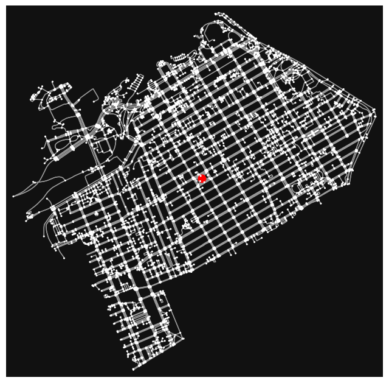

```python
nc = ["r" if node == max_node else "w" for node in graph.nodes]
ns = [100 if node == max_node else 5 for node in graph.nodes]
fig, ax = ox.plot_graph(graph, node_size=ns, node_color=nc, node_zorder=2)
```

~15% of all shortest paths run through the node highlighted in red. Let's look at the relative betweenness centrality of every node in the graph:

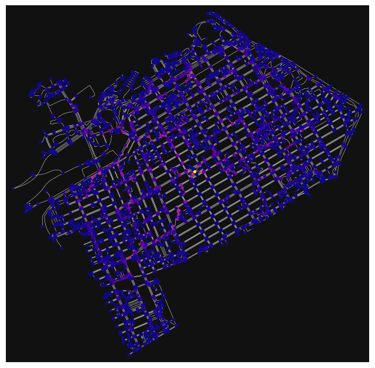

```python
# add the betweenness centraliy values as new node attributes, then plot
nx.set_node_attributes(graph, bc, "bc")
nc = ox.plot.get_node_colors_by_attr(graph, "bc", cmap="plasma")
fig, ax = ox.plot_graph(
    graph,
    node_color=nc,
    node_size=15,
    node_zorder=2,
    edge_linewidth=0.2,
    edge_color="w",
)
```

Above, the nodes are visualized by betweenness centrality, from low (dark violet) to high (light yellow). The colors in the colorspace are linearly mapped to the attribute values.

## Conclusion

In conclusion, our analysis of Somerset, Ottawa's street network has provided valuable information about its layout and connectivity. The findings reveal that the area has a well-connected network, a diverse range of intersections, and a compact urban structure. The betweenness centrality analysis helps identify important streets and intersections, which can be useful for decision-makers when planning future development or improvements in the area.

## Ideas for Enhancement

In this notebook, our aim was to maintain simplicity while conveying the results effectively. For future enhancements, we have considered the following ideas:

- Interactive Maps: integrating interactive maps with libraries such as Folium or ipyleaflet, which would enable users to more effectively zoom in and examine the study area.
- Dynamic Parameters: Implement Jupyter widgets to let users modify parameters, like walking distance or selected amenities.
- Compare Multiple Areas: Offer the option for users to input various locations, allowing them to compare and analyze different neighborhoods or cities using the same indicators and visualizations.